# mlr3torch

Sebastian Fischer

2022-07-15

## What is mlr3torch

mlr3torch can be seen as the successor to mlr3keras and extends the mlr3verse to deep learning. This means that:

1. It is possible to train neural networks implemented in {torch}
2. It adds a new feature type `"imageuri"` that extends mlr3 to images.

There are three levels of control for how neural network architectures can be defined, sorted by the amount of control you have over the network architecture:

- Predefined architectures implemented as Learners
- Define neural networks using [TorchOp]s
- Fully custom neural networks defined as `nn_module`s

## Quickstart

We will now show how briefly how to use the three levels of control and afterwards explain the new feature type `"imageuri"`.

For the first part, we will use the classic “spirals” task.

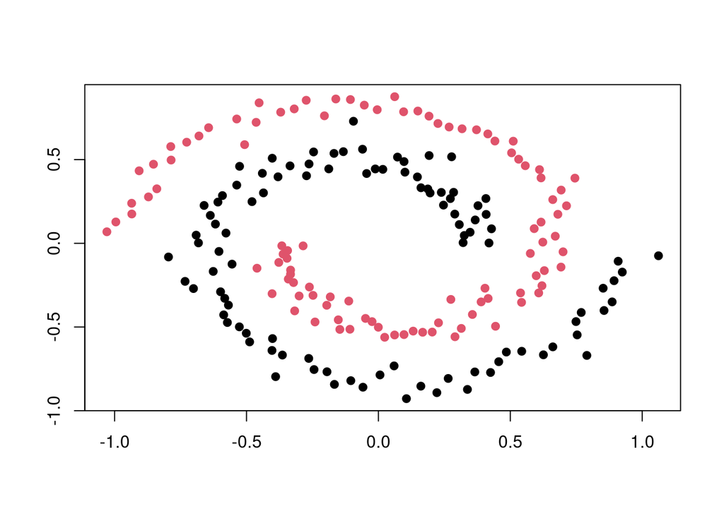

```r
gen = tgen("spirals", sd = 0.05)
plot(gen)
```

```r
task = gen$generate(n = 100L)
```

After loading mlr3torch, we can see that we have new learners available:

```r
library(mlr3torch)
as.data.table(mlr_learners)[, .(key, label)]
```

```
## Key: <key>
##                     key                              label
##                  <char>                             <char>
##  1:     classif.alexnet           AlexNet Image Classifier
##  2:       classif.debug   Debug Learner for Classification
##  3: classif.featureless Featureless Classification Learner
##  4:         classif.mlp             Multi Layer Perceptron
##  5:       classif.rpart                Classification Tree
##  6:  classif.tab_resnet                     Tabular ResNet
##  7:      classif.tabnet                               <NA>
##  8:       classif.torch             Classification Network
##  9:          regr.debug       Debug Learner for Regression
## 10:    regr.featureless     Featureless Regression Learner
## 11:          regr.rpart                    Regression Tree
## 12:         regr.tabnet                               <NA>
```

```r
learner = lrn("classif.mlp", optimizer = "adam", loss = "cross_entropy")
```

We set `optimizer = "adam"` and `loss = "cross_entropy"`. Note that these are construction arguments and not parameters, meaning they cannot be altered after the learner has been constructed.

The reason for this is that the learner now automatically inferred the parameters of the optimizer (prefixed by `opt.`) and the loss function (prefixed by `loss.`).

There are three parameters that allow to configure the network architecture. The parameter `layers` determines the number of latent layers with dimension `d_hidden`. The dropout probability is given by the parameter `p`.

Apart from these specific parameters there are generic parameters that are available for almost all torch networks and that allow to configure the training process. They include the number of epochs, the batch size or the device and will be addressed in this section.

```r
learner$param_set
```

```
## <ParamSetCollection>
##                       id    class lower upper nlevels        default     value
##                   <char>   <char> <num> <num>   <num>         <list>    <list>
##  1:         augmentation ParamUty    NA    NA     Inf <NoDefault[3]>
##  2:           batch_size ParamInt 1e+00   Inf     Inf             16
##  3:            callbacks ParamUty    NA    NA     Inf <NoDefault[3]>
##  4:               device ParamFct    NA    NA       4           auto
##  5:            drop_last ParamLgl    NA    NA       2          FALSE     FALSE
##  6:               epochs ParamInt 0e+00   Inf     Inf <NoDefault[3]>
##  7: keep_last_prediction ParamLgl    NA    NA       2           TRUE
##  8:             measures ParamUty    NA    NA     Inf <NoDefault[3]> <list[0]>
##  9:          num_threads ParamInt 1e+00   Inf     Inf              1         1
## 10:              shuffle ParamLgl    NA    NA       2           TRUE      TRUE
## 11:          valid_split ParamDbl 0e+00 1e+00     Inf           0.33      0.33
## 12:              network ParamUty    NA    NA     Inf <NoDefault[3]>
## 13:               opt.lr ParamDbl 0e+00   Inf     Inf          0.001
## 14:            opt.betas ParamUty    NA    NA     Inf    0.900,0.999
## 15:              opt.eps ParamDbl 1e-16 1e-04     Inf          1e-08
## 16:     opt.weight_decay ParamDbl 0e+00 1e+00     Inf              0
## 17:          opt.amsgrad ParamLgl    NA    NA       2          FALSE
## 18:          loss.weight ParamUty    NA    NA     Inf <NoDefault[3]>
## 19:    loss.ignore_index ParamInt  -Inf   Inf     Inf <NoDefault[3]>
## 20:       loss.reduction ParamFct    NA    NA       2           mean
## 21:           activation ParamFct    NA    NA      20           relu      relu
## 22:      activation_args ParamUty    NA    NA     Inf      <list[0]>
## 23:               layers ParamInt 1e+00   Inf     Inf <NoDefault[3]>
## 24:             d_hidden ParamInt 1e+00   Inf     Inf <NoDefault[3]>
## 25:                    p ParamDbl 0e+00 1e+00     Inf            0.5
##                       id    class lower upper nlevels        default     value
```

We now set some of the previously mentioned parameters.

```r
pars = list(
  layers = 2,
  d_hidden = 50,
  p = 0.2,
  activation = "tanh",
  epochs = 10,
  batch_size = 100,
  opt.lr = 0.3
)
learner$param_set$values = insert_named(learner$param_set$values, pars)
```

The second way to define the network is to use [LearnerClassifTorch] or [LearnerClassifRegr] and set the parameter `network` to an `"nn_module()"`. To know how to define this, it is important to know the structure of the data that is output by the dataloader. For tasks that only contain tabular data, the output is a named list `list(num = ..., cat = ...)`. Where the element `num` is a tensor of type float containing all the numeric observations (`double` or `integer`), while the element `cat` is a tensor of type long, containing all the categorical observations encoded as intgegers.

```r
library(torch)
my_module = nn_module(
  "nn_linear",
  initialize = function(in_features, out_features) {
    self$linear = nn_linear(in_features, out_features)
  },
  forward = function(input) {
    x = input$num
    x = self$linear(x)
    return(x)
  }
)

# 4 features and 3 classes
my_network = my_module(4, 3)

learner = lrn(
  "classif.torch",
  network = my_network,
  optimizer = "adam", # optimizer
  epochs = 20L,  # number of epochs
  opt.lr = 0.5,
  batch_size = 64L, # the batch size
  device = "cpu", # where the computations take place
  loss = "cross_entropy" # loss for trainig
)

#learner$train(task)
#p = learner$predict(task)
#p$score(msr("classif.acc"))
```

### Understanding TorchOps

Readers should be familiar with mlr3pipelines. To how a Graph consisting of TorchOps works, we have to distinguish between the training and the prediction phase.

**Training phase** All but TorchOpInput and TorchOpModel take as input an object of class `"ModelConfig"` and output an object of class `"ModelConfig"`